# Diseño y análisis de experimentos - PEC 1

Candela Sánchez

7 de April, 2026

# Problema 1 (80%)

## PRODUCCIÓN DE POLOHIDROXIALCANOATOS (PHA) A PARTIR DE RESIDUOS AGROINDUSTRIALES MEDIANTE *Cupriavidus necator*

```r
# Creamos un dataframe con los datos de la tabla
datos <- data.frame(
  Fuente= factor(rep(c("Glucosa", "Glicerol", "Maíz", "Suero"), each=3)),
  PHA= c(63.8, 60.3, 64.2, # Glucosa
         51.7, 58.6, 47.5, # Glicerol
         68.1, 63.0, 60.5, # Maíz
         19.7, 20.3, 24.8) # Suero
)
# Verificamos la media global y la desviacion estandar
media_global <- mean(datos$PHA)
cat("Media global:", media_global, "\n")
```

```
## Media global: 50.20833
```

```r
desv_std <- sd(datos$PHA)
cat("Desviación estándar:", desv_std,"\n" )
```

```
## Desviación estándar: 18.14795
```

Podemos observar que tanto la media global como la desviación estandar son las mismas que el enunciado.

### 1. Enunciar la hipótesis experimental que se plantea en este estudio.

La hipóteis experimental de este estudio es comprobar si el tipo de residuo agroindustrial influye significativamente en la acumulación de PHA en cultivos de *Cupriavius necator*.

### 2. Explorar gráficamente los datos para comprobar si dicha hipótesis es razonable.

Para visualizar si hay diferencias entre los diferentes tipos de residuos agroindustriales realizamos un boxplot.

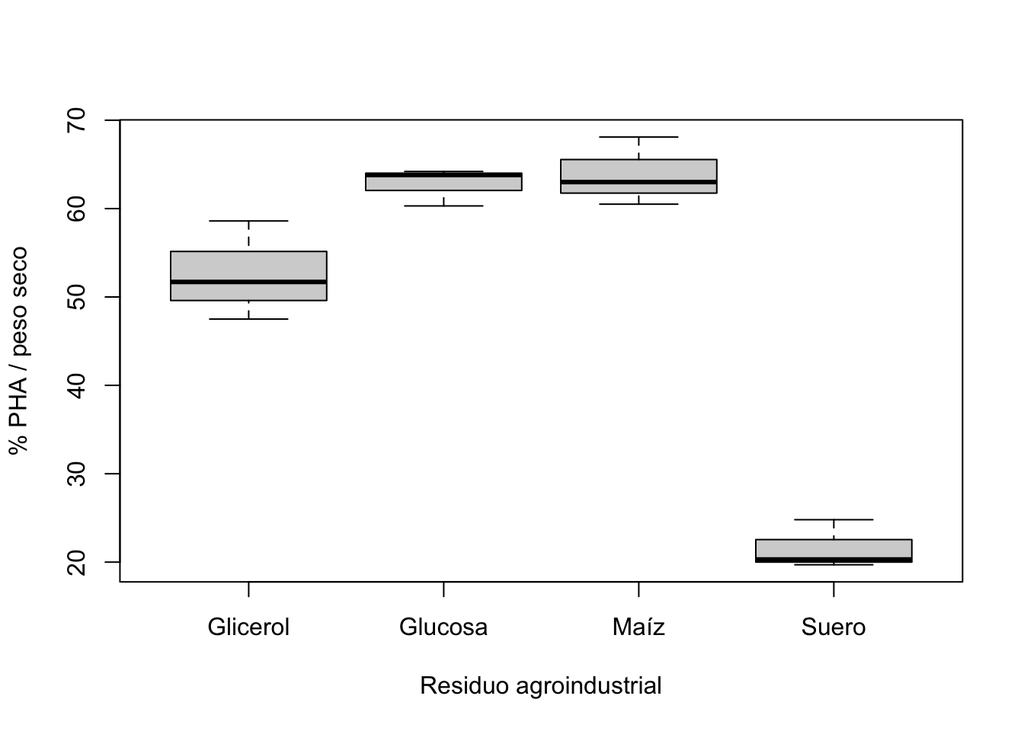

```r
# Exploramos gráficamente los datos mediante un boxplot
boxplot(PHA~Fuente,
        data=datos,
        ylab= "% PHA / peso seco",
        xlab= "Residuo agroindustrial")
```

En el diagrama de cajas (boxplot) se puede observar que hay diferencias en la acumulación de PHA según la fuente de carbono utilizada.

Para contrastar que las diferencias que hay según la fuente de carbono son estadísticamente significativas se puede realizar un test de ANOVA. Además, añadir que la hipótesis planteada es razonable.

### 3. Formular el modelo lineal necesario para abordar el problema anterior, detallando todos los parámetros que intervienen y las suposiciones de la modelización.

Para este estudio vamos a utilizar el siguiente modelo lineal:

$y_{ij}$ = $\mu$ + $\alpha_{i}$ + $\epsilon_{ij}$ con la restricción $\sum_{i=1}^{4} \alpha_i = 0$.

Donde:

- $y_{ij}$ es la variable respuesta, es decir, el porcentaje de PHA acumulado respecto al peso seco.
- $\mu$ es la media global de la acumulación de PHA.
- $\alpha_{i}$ es el efecto del nivel i, es decir, el efecto que tiene cada condición.
- $\epsilon_{ij}$ es el error experimental o residuo.

Para que este modelo sea valido, los residuos deben cumplir las siguientes suposiciones de modelización:

- Las observaciones son independientes entre sí.
- La varianza de errores es constante en todos los niveles.
- $\epsilon_{ij}$ sigue una distribución normal $\epsilon_{ij} \sim N(0, \sigma^2)$.

### 4. Realizar la diagnosis de las suposiciones de modelización.

Para realizar la diagnosis de las suposiciones de modelización analizamos la normalidad de los residuos y la homocedasticidad.

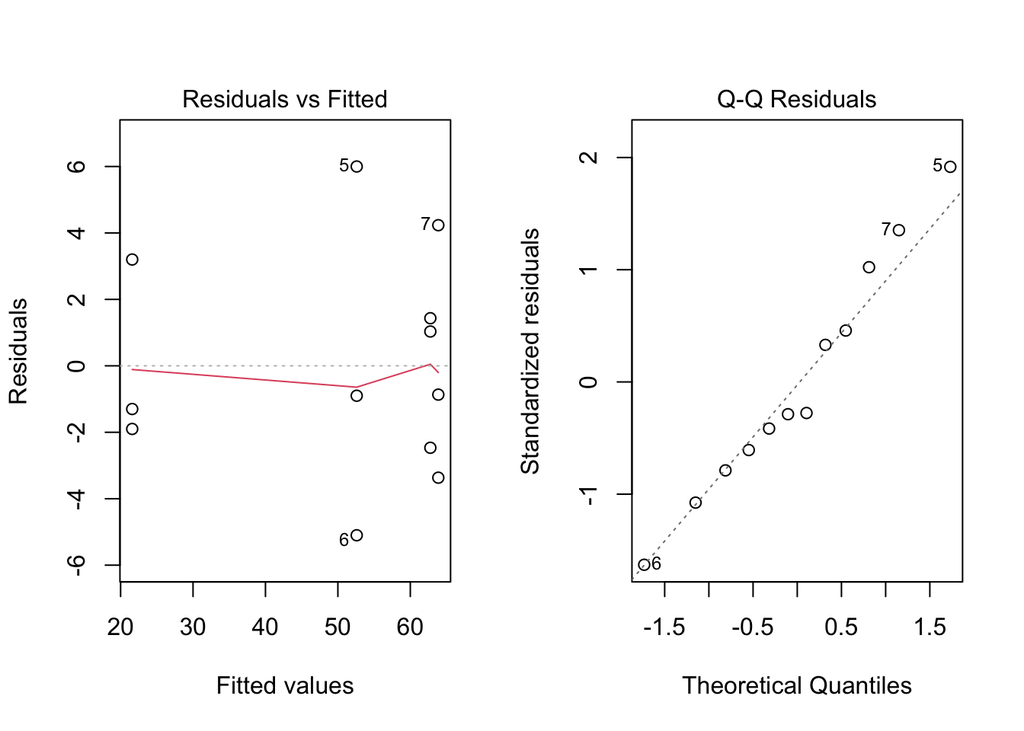

```r
# Ajustamos el modelo
modelo <- aov(PHA~Fuente, data = datos)

# Gráficos de homocedasticidad y normalidad
par(mfrow= c(1,2))
plot(modelo, which=1) # Homocedasticidad
plot(modelo, which=2) # Normalidad
```

```r
# Realizamos el test de normalidad mediante Shapiro-Wilk
shapiro.test(residuals(modelo))
```

```
##
##  Shapiro-Wilk normality test
##
## data:  residuals(modelo)
## W = 0.97002, p-value = 0.911
```

```r
# Realizamos el test de homocedasticidad mediante Levene
library(car)
leveneTest(PHA~Fuente, data=datos)
```

|  | Df | F value | Pr(>F) |
| --- | --- | --- | --- |
| group | 3 | 0.4780401 | 0.7063749 |
|  | 8 | NA | NA |

En el gráfico de residuos frente a los valores ajustados, se observa que los residuos se distribuyen de manera aleatoria indicando que hay una varianza constante, es decir, homocedasticidad. Por otro lado, en el gráfico de normalidad, los puntos se alinean sobre la diagonal indicando que los errores siguen una distribución normal.

En cuanto a los tests de Shapiro-Wilk y Levene se confirma que hay normalidad y homocedasticidad ya que el p-valor es mayor a 0.05.

### 5. Especificar la hipótesis estadística que se contrasta mediante el ANOVA. Expresarla primero en lenguaje natural y posteriormente en términos paramétricos. Presentar la tabla ANOVA e indicar qué conclusiones se obtienen.

Para determinar si la fuente de carbono influye significativamente en la acumulación de PHA, contrastamos las siguientes hipótesis:

- Hipótesis nula ($H_0$) si no existen diferencias significativas en el porcentaje medio de PHA acumulado entre las diferentes fuentes de carbono. En términos paramétricos: $H_0: \alpha_1 = \alpha_2 = \alpha_3 = \alpha_4 = 0$.
- Hipótesis alternativa ($H_1$) si al menos una de las fuentes de carbono produce un porcentaje medio de PHA significativamente diferente a las demas. En términos paramétricos: $H_1: \exists \alpha_i \neq 0$ para algún $i \in \{1, 2, 3, 4\}$.

```r
anova(modelo)
```

|  | Df | Sum Sq | Mean Sq | F value | Pr(>F) |
| --- | --- | --- | --- | --- | --- |
| Fuente | 3 | 3505.2558 | 1168.41861 | 79.50229 | 2.694205e-06 |
| Residuals | 8 | 117.5733 | 14.69667 | NA | NA |

El p-valor es $2.694 \times 10^{-6}$, un valor muy inferior a $\alpha = 0.05$. Por tanto, rechazamos la hipótesis nula, lo que indica que existen diferencias estadisticamente significativas entre las diferentes fuentes de carbono.

### 6. Encontrar las estimaciones de los parámetros del modelo.

```r
# Calculamos la media general y las medias de las diferentes fuentes de carbono
model.tables(modelo, type = "means")
```

```
## Tables of means
## Grand mean
##
## 50.20833
##
##  Fuente
## Fuente
## Glicerol  Glucosa     Maíz    Suero
##    52.60    62.77    63.87    21.60
```

Sabiendo que la media general es 50.208, calculamos las estimaciones de los parámetros del modelo:

```r
model.tables(modelo, type = "effects")
```

```
## Tables of effects
##
##  Fuente
## Fuente
## Glicerol  Glucosa     Maíz    Suero
##    2.392   12.558   13.658  -28.608
```

La estimación de la varianza del error se obtiene de la tabla ANOVA presentada en el apartado anterior. Por lo que ${\sigma}^2 = 14.7$.

### 7. ¿Es pertinente considerar las comparaciones múltiples? En caso afirmativo, realizar las comparaciones múltiples.

En el apartado 5, se ha visto que el p-valor<0.05 indicando un resultado de ANOVA altamente significativo. Por lo que al menos una de las fuentes de carbono es diferente a las demás, pero no se sabe cuál es la fuente y tampoco cuántas son diferentes. Para ello, es pertinente considerar las comparaciones múltiples para obtener más información.

Se va a utilizar el Test de Tukey para realizar las comparaciones múltiples.

```r
# Cargamos los paquetes necesarios
library(agricolae)
# Realizamos el test de Tukey al modelo
test_tukey <- HSD.test(modelo, "Fuente", console=TRUE)
```

```
##
## Study: modelo ~ "Fuente"
##
## HSD Test for PHA
##
## Mean Square Error:  14.69667
##
## Fuente,  means
##
##               PHA      std r       se  Min  Max   Q25  Q50   Q75
## Glicerol 52.60000 5.604463 3 2.213343 47.5 58.6 49.60 51.7 55.15
## Glucosa  62.76667 2.145538 3 2.213343 60.3 64.2 62.05 63.8 64.00
## Maíz     63.86667 3.873414 3 2.213343 60.5 68.1 61.75 63.0 65.55
## Suero    21.60000 2.787472 3 2.213343 19.7 24.8 20.00 20.3 22.55
##
## Alpha: 0.05 ; DF Error: 8
## Critical Value of Studentized Range: 4.52881
##
## Minimun Significant Difference: 10.02381
##
## Treatments with the same letter are not significantly different.
##
##               PHA groups
## Maíz     63.86667      a
## Glucosa  62.76667      a
## Glicerol 52.60000      b
## Suero    21.60000      c
```

El test clasifica las fuentes de carbono en tres grupos. El grupo a formado por el maíz y la glucosa, las cuales no presentan diferencias significativas entre sí; el grupo b formado por el glicerol y el grupo c formado por el suero.

### 8. Indicar qué fuente de carbono presenta mayor acumulación de PHA. ¿Es significativamente superior al resto? Proporcionar un intervalo de confianza al 95% para la media correspondiente.

En el apartado anterior se puede observar que el maiz presenta la mayor acumulación media de PHA, siendo esta de un 63.9%.

Si que es significativamente mayor que el glicerol y el suero, pero no hay diferencias estadísticamente significativas respecto a la glucosa.

```r
# Calculamos el intervalo de confianza
interv_conf <- LSD.test(modelo, "Fuente", alpha = 0.05, console = TRUE)
```

```
##
## Study: modelo ~ "Fuente"
##
## LSD t Test for PHA
##
## Mean Square Error:  14.69667
##
## Fuente,  means and individual ( 95 %) CI
##
##               PHA      std r       se      LCL      UCL  Min  Max   Q25  Q50
## Glicerol 52.60000 5.604463 3 2.213343 47.49602 57.70398 47.5 58.6 49.60 51.7
## Glucosa  62.76667 2.145538 3 2.213343 57.66269 67.87065 60.3 64.2 62.05 63.8
## Maíz     63.86667 3.873414 3 2.213343 58.76269 68.97065 60.5 68.1 61.75 63.0
## Suero    21.60000 2.787472 3 2.213343 16.49602 26.70398 19.7 24.8 20.00 20.3
##            Q75
## Glicerol 55.15
## Glucosa  64.00
## Maíz     65.55
## Suero    22.55
##
## Alpha: 0.05 ; DF Error: 8
## Critical Value of t: 2.306004
##
## least Significant Difference: 7.218116
##
## Treatments with the same letter are not significantly different.
##
##               PHA groups
## Maíz     63.86667      a
## Glucosa  62.76667      a
## Glicerol 52.60000      b
## Suero    21.60000      c
```

El intervalo de confianza del 95% del maíz se situa entre el 58.76% y el 68.97%.

### 9. Calcular el tamaño muestral necesario para detectar dos fuentes de carbono que difieran de la media global en ±5 unidades porcentuales, manteniendo el resto con la media global. Especificar un nivel de significación del 5% y una potencia del 90%. Utilizar como estimación de la varianza residual la obtenida en el apartado 6.

Para determinar el tamaño muestral necesario, definimos los siguientes parámtros para utilizar el método *power.anova.test*:

- El número de grupos es 4.
- La media global es 50.208, pero como dos fuentes de carbono difieren en $\pm 5$ unidades de la media global y las otras dos coinciden con ella, las medias son: medias <- c(50.208 + 5, 50.208 - 5, 50.208, 50.208).
- La varianza entre grupos se calcula hallando la varianza de las medias
- La varianza residual, obtenida en el apartado 6, es 14.7.
- La significación es 0.05.
- La potencia es 0.9.

```r
# Calculamos las medias
medias <- c(50.208 + 5, 50.208 - 5, 50.208, 50.208)

# Calculamos el tamaño muestral
power.anova.test(groups = 4, n=NULL, between.var = var(medias), within.var = 14.7, sig.level = 0.05, power = 0.9)
```

```
##
##      Balanced one-way analysis of variance power calculation
##
##          groups = 4
##               n = 5.264629
##     between.var = 16.66667
##      within.var = 14.7
##       sig.level = 0.05
##           power = 0.9
##
## NOTE: n is number in each group
```

El tamaño muestral necesario para detectar dos fuentes de carbono que difieran de la media global en $\pm 5$ unidades porcentuales, manteniendo el resto con la media global debe ser 6.

### 10. Resolver el contraste principal (ver el punto 5) mediante un test de permutaciones. Comparar los resultados con los obtenidos mediante el ANOVA clásico y comentar.

```r
# Cargamos los paquetes necesarios
library(lmPerm)
set.seed(123) # Aseguramos la reproducibilidad
# Realizamos un test de permutaciones
test_permutaciones <- aovp(PHA~Fuente, data = datos)
```

```
## [1] "Settings:  unique SS "
```

```r
summary(test_permutaciones)
```

```
## Component 1 :
##             Df R Sum Sq R Mean Sq Iter Pr(Prob)
## Fuente       3   3505.3    1168.4 5000    4e-04 ***
## Residuals    8    117.6      14.7
## ---
## Signif. codes:  0 '***' 0.001 '**' 0.01 '*' 0.05 '.' 0.1 ' ' 1
```

El ANOVA clásico proporcionó un p-valor de $2.694 \times 10^{-6}$, mientras que el p-valor del test de permutaciones es de $4 \times 10^{-4}$. Aunque este valor sea algo mayor, ambos resultados son altamente significativos ya que son menores a 0.05. La hipótesis nula se seguiría rechazando, por lo que al menos una de las fuentes de carbono produce un porcentaje medio de PHA significativamente diferente a las demas.

# Problema 2 (10%)

En el análisis de los datos de un experimento con un ANOVA de un factor correspondiente a un diseño balanceado, se dispone de la siguiente tabla incompleta:

| Fuente.de.variación | gl | SS | MS | F |
| --- | --- | --- | --- | --- |
| Grupo | 5 |  | 11.8 | 20.6 |
| Residuals |  | 13.7 |  |  |
| Total |  |  |  |  |

Se pide:

### 1. Completar la tabla ANOVA

Para completar la tabla tenemos en cuenta las siguientes relaciones:

- $MS = SS / gl$, por lo que $SS = MS \cdot gl$
  - $SS_{Grupo}=11.8\cdot 5=59$
- $F = MS_{Grupo} / MS_{Residuals}$, por lo que $MS_{Residuals} = MS_{Grupo} / F$
  - $MS_{Residuals} = 11.8 / 20.6= 0.57$
- $gl_{Residuals} = SS_{Residuals} / MS_{Residuals}$
  - $gl_{Residuals} = 13.7 / 0.57=24$

Por lo que tabla completa sería de la siguiente manera:

| Fuente.de.variación | gl | SS | MS | F |
| --- | --- | --- | --- | --- |
| Grupo | 5 | 59.0 | 11.8 | 20.6 |
| Residuals | 24 | 13.7 | 0.57 |  |
| Total | 29 | 72.7 |  |  |

### 2. Si las medias de los grupos son: $\bar{y}_1 = 4.6$, $\bar{y}_2 = 5.3$, $\bar{y}_3 = 4.5$, $\bar{y}_4 = 6.8$, $\bar{y}_5 = 7.1$, $\bar{y}_6 = 8.3$, calcular el valor LSD y determinar qué comparaciones por parejas son significativas con un nivel de significación del 5%.

La formula de LSD es: $LSD = t_{N-a, \epsilon/2} \sqrt{MSE \cdot \frac{2}{n}}$ y sabemos que:

- $n=5$
- $a=6$
- $N=30$
- $\epsilon = 0.05$
- $MSE=0.57$

```r
# Calculamos LSD
LSD=qt(0.975, 24)*sqrt(2*0.57/5)
print(LSD)
```

```
## [1] 0.9854981
```

Para determinar qué comparaciones por parejas son significativas, tenemos que calcular $|\bar{y}_i - \bar{y}_j|$ de todos los pares.

$|\bar{y}_{1\cdot} - \bar{y}_{2\cdot}| = |4.6 - 5.3| = 0.7$

$|\bar{y}_{1\cdot} - \bar{y}_{3\cdot}| = |4.6 - 4.5| = 0.1$

$|\bar{y}_{1\cdot} - \bar{y}_{4\cdot}| = |4.6 - 6.8| = 2.2$

$|\bar{y}_{1\cdot} - \bar{y}_{5\cdot}| = |4.6 - 7.1| = 2.5$

$|\bar{y}_{1\cdot} - \bar{y}_{6\cdot}| = |4.6 - 8.3| = 3.7$

$|\bar{y}_{2\cdot} - \bar{y}_{3\cdot}| = |5.3 - 4.5| = 0.8$

$|\bar{y}_{2\cdot} - \bar{y}_{4\cdot}| = |5.3 - 6.8| = 1.5$

$|\bar{y}_{2\cdot} - \bar{y}_{5\cdot}| = |5.3 - 7.1| = 1.8$

$|\bar{y}_{2\cdot} - \bar{y}_{6\cdot}| = |5.3 - 8.3| = 3.0$

$|\bar{y}_{3\cdot} - \bar{y}_{4\cdot}| = |4.5 - 6.8| = 2.3$

$|\bar{y}_{3\cdot} - \bar{y}_{5\cdot}| = |4.5 - 7.1| = 2.6$

$|\bar{y}_{3\cdot} - \bar{y}_{6\cdot}| = |4.5 - 8.3| = 3.8$

$|\bar{y}_{4\cdot} - \bar{y}_{5\cdot}| = |6.8 - 7.1| = 0.3$

$|\bar{y}_{4\cdot} - \bar{y}_{6\cdot}| = |6.8 - 8.3| = 1.5$

$|\bar{y}_{5\cdot} - \bar{y}_{6\cdot}| = |7.1 - 8.3| = 1.2$

Las comparaciones por parejas que son significativas son las que son mayores a LSD, es decir, cuando son mayores a 0.98. En este caso, son las comporaciones 1-4, 1-5, 1-6, 2-4, 2-5, 2-6, 3-4, 3-5, 3-6, 4-6 y 5-6.

# Problema 3 (10%)

### 1. Comentar brevemente (máximo 5 líneas) la respuesta proporcionada.

La respuesta de la IA explica que ambos métodos usan una misma fórmula, pero con distintos fines, ya que la regresión usa números (como la altura) para ver si hay tendencias y pendientes, y el ANOVA usa categorías (como colores) para comparar promedios y ver si los grupos son diferentes entre sí. En resumen, la diferencia principal está en el tipo de datos que utiliza para explicar el problema.

### 2. Comentar brevemente (máximo 5 líneas) la respuesta proporcionada.

En este caso, nos explica que si tenemos números y categorías a la vez, hay un modelo que se puede utilizar llamado ANCOVA. Este modelo permite observar como varía la tendencia según el grupo al que perteneces (ANOVA). En resumen, sirve para comparar grupos de manera mas justa, teniendo en cuenta que hay otros datos numéricos que influyen.